# Assignment-2023, Semester 1

## Student Details:

- Name: P M J
- Date: 11 April 2023

## TASK 1: Problem Formulation, Data Acquisition and Preparation

I have chosen to analyze the Adult data set which aims to predict whether income exceeds $50,000 per year based on census data.

I will import the standard data science toolkit then import the data and inspect, clean and munge the data set.

```python
# Import all necessary python libraries
import pandas as pd # pandas to manipulate data and provide data structure
import numpy as np # numpy to create arrays and matrices
import matplotlib.pyplot as plt # matplotlib to create visualizations
import scipy.stats as stats # scipy stats to conduct analysis of variables
from sklearn.model_selection import train_test_split # sklearn to use algorithms
from sklearn.metrics import confusion_matrix, accuracy_score, precision_score, recall_score, f1_score
from sklearn.linear_model import LogisticRegression
from sklearn.tree import DecisionTreeClassifier
from sklearn.preprocessing import LabelEncoder
import seaborn as sns # seaborn to add beauty to visualizations
```

### My observations after including the raw data set in my folder

- The data set was downloaded as adult.data.
- After opening the file in Jypyter, I see that values are separated by commas.
- There are 32,561 rows of data.
- There is no header row.

```python
# Define column names based on the contents of adult.data
col_names = ['age', 'workclass', 'fnlwgt', 'education', 'education_num', 'marital_status', 'occupation', 'relationship', 'race', 'sex', 'capital_gain', 'capital_loss', 'hours_per_week', 'native_country', 'income']

# Load the data into a data frame with Pandas
df = pd.read_csv('adult.data', names=col_names, header=None, na_values='?')

# Replace ' ? ' with NaN
df.replace(' ?', np.nan, inplace=True)

# Handle missing values by dropping rows with missing values
df.dropna(inplace=True)
```

### Check that the data was imported correctly

```python
# Check the head of the adult dataframe df
df.head()
```

|  | age | workclass | fnlwgt | education | education_num | marital_status | occupation | relationship | race | sex | capital_gain | capital_loss | hours_per_week | native_country | income |
| --- | --- | --- | --- | --- | --- | --- | --- | --- | --- | --- | --- | --- | --- | --- | --- |
| 0 | 39 | State-gov | 77516 | Bachelors | 13 | Never-married | Adm-clerical | Not-in-family | White | Male | 2174 | 0 | 40 | United-States | <=50K |
| 1 | 50 | Self-emp-not-inc | 83311 | Bachelors | 13 | Married-civ-spouse | Exec-managerial | Husband | White | Male | 0 | 0 | 13 | United-States | <=50K |
| 2 | 38 | Private | 215646 | HS-grad | 9 | Divorced | Handlers-cleaners | Not-in-family | White | Male | 0 | 0 | 40 | United-States | <=50K |
| 3 | 53 | Private | 234721 | 11th | 7 | Married-civ-spouse | Handlers-cleaners | Husband | Black | Male | 0 | 0 | 40 | United-States | <=50K |
| 4 | 28 | Private | 338409 | Bachelors | 13 | Married-civ-spouse | Prof-specialty | Wife | Black | Female | 0 | 0 | 40 | Cuba | <=50K |

```python
# Check the tail of the adult dataframe df
df.tail()
```

|  | age | workclass | fnlwgt | education | education_num | marital_status | occupation | relationship | race | sex | capital_gain | capital_loss | hours_per_week | native_country | income |
| --- | --- | --- | --- | --- | --- | --- | --- | --- | --- | --- | --- | --- | --- | --- | --- |
| 32556 | 27 | Private | 257302 | Assoc-acdm | 12 | Married-civ-spouse | Tech-support | Wife | White | Female | 0 | 0 | 38 | United-States | <=50K |
| 32557 | 40 | Private | 154374 | HS-grad | 9 | Married-civ-spouse | Machine-op-inspct | Husband | White | Male | 0 | 0 | 40 | United-States | >50K |
| 32558 | 58 | Private | 151910 | HS-grad | 9 | Widowed | Adm-clerical | Unmarried | White | Female | 0 | 0 | 40 | United-States | <=50K |
| 32559 | 22 | Private | 201490 | HS-grad | 9 | Never-married | Adm-clerical | Own-child | White | Male | 0 | 0 | 20 | United-States | <=50K |
| 32560 | 52 | Self-emp-inc | 287927 | HS-grad | 9 | Married-civ-spouse | Exec-managerial | Wife | White | Female | 15024 | 0 | 40 | United-States | >50K |

```python
# Check the unique values of each column
for col in df.columns:
    print(f"Column: {col}")
    print(df[col].unique())
```

```
Column: age
[39 50 38 53 28 37 49 52 31 42 30 23 32 34 25 43 40 54 35 59 56 19 20 45
 22 48 21 24 57 44 41 29 47 46 36 79 27 18 33 76 55 61 70 64 71 66 51 58
 26 17 60 90 75 65 77 62 63 67 74 72 69 68 73 81 78 88 80 84 83 85 82 86]
Column: workclass
[' State-gov' ' Self-emp-not-inc' ' Private' ' Federal-gov' ' Local-gov'
 ' Self-emp-inc' ' Without-pay']
Column: fnlwgt
[ 77516  83311 215646 ...  84661 257302 201490]
Column: education
[' Bachelors' ' HS-grad' ' 11th' ' Masters' ' 9th' ' Some-college'
 ' Assoc-acdm' ' 7th-8th' ' Doctorate' ' Assoc-voc' ' Prof-school'
 ' 5th-6th' ' 10th' ' Preschool' ' 12th' ' 1st-4th']
Column: education_num
[13  9  7 14  5 10 12  4 16 11 15  3  6  1  8  2]
Column: marital_status
[' Never-married' ' Married-civ-spouse' ' Divorced'
 ' Married-spouse-absent' ' Separated' ' Married-AF-spouse' ' Widowed']
Column: occupation
[' Adm-clerical' ' Exec-managerial' ' Handlers-cleaners' ' Prof-specialty'
 ' Other-service' ' Sales' ' Transport-moving' ' Farming-fishing'
 ' Machine-op-inspct' ' Tech-support' ' Craft-repair' ' Protective-serv'
 ' Armed-Forces' ' Priv-house-serv']
Column: relationship
[' Not-in-family' ' Husband' ' Wife' ' Own-child' ' Unmarried'
 ' Other-relative']
Column: race
[' White' ' Black' ' Asian-Pac-Islander' ' Amer-Indian-Eskimo' ' Other']
Column: sex
[' Male' ' Female']
Column: capital_gain
[ 2174     0 14084  5178  5013  2407 14344 15024  7688  4064  4386  7298
  1409  3674  1055  2050  2176   594 20051  6849  4101  8614  3411  2597
 25236  4650  2463  3103 10605  2964  3325  2580  3471  4865 99999  6514
  1471  2329  2105  2885 10520  2202  2961 27828  6767  2228  1506 13550
  2635  5556  4787  3781  3137  3818   914   401  2829  2977  4934  2062
  2354  3464  5455 15020  1424  3273 22040  4416 10566  4931  7430 34095
  6497  3908   114  2346  2907  1151  9386  2414  2290  3418 15831 41310
  4508  2538  3456  1848  3887  7896  5721  9562  6418  1455  2036  3942
  1831 11678  2936  2993  7443  6360  4687  1797  6723  2009  3432  6097
```

[output cut: 10 more lines]

```
[40 13 16 45 50 80 30 35 60 20 52 44 15 25 43 38 55 48 58 32 70 22 56 41
 28 36 24 46  2 42 12 65  1 34 75 98 33 54 10  6 64 19 18 72  8  9 47 37
 21 26 14  5  7 99 53 39 62 59 57 78 90 66 11 49 84 17 68  3 27 85 31 51
 77 63 23  4 87 88 73 89 97 94 29 96 67 82 86 91 81 76 92 61 74 95]
Column: native_country
[' United-States' ' Cuba' ' Jamaica' ' India' ' Mexico' ' Puerto-Rico'
 ' Honduras' ' England' ' Canada' ' Germany' ' Iran' ' Philippines'
 ' Poland' ' Columbia' ' Cambodia' ' Thailand' ' Ecuador' ' Laos'
 ' Taiwan' ' Haiti' ' Portugal' ' Dominican-Republic' ' El-Salvador'
 ' France' ' Guatemala' ' Italy' ' China' ' South' ' Japan' ' Yugoslavia'
 ' Peru' ' Outlying-US(Guam-USVI-etc)' ' Scotland' ' Trinadad&Tobago'
 ' Greece' ' Nicaragua' ' Vietnam' ' Hong' ' Ireland' ' Hungary'
 ' Holand-Netherlands']
Column: income
[' <=50K' ' >50K']
```

### My observations after giving the data a prima facie glance:

- The *income* column resembles boolean data
- The *fnlwgt* column indicates the number of people the census believes the data point represents.
- The *education_num* column indicates how many years a data point spent in education.
- The *capital_gain* and *capital_loss* indicate the loss or gain incurred by a data point disposing of an asset.
- The label in this dataset is income. This is a binary label of either <=50k or >50k

## Task 2: Data Exploration

### Task 2.1: Explore each column

Each column will be explored using descriptive statistics and graphical visualizations where necessary.

```python
# Describe each column
print('Age Column')
print(df['age'].describe())

print('Workclass Column')
print(df['workclass'].describe())

print('Final Weight Column')
print(df['fnlwgt'].describe())

print('Education Column')
print(df['education'].describe())

print('Years in Education Column')
print(df['education_num'].describe())

print('Marital Status Column')
print(df['marital_status'].describe())

print('Occupation Column')
print(df['occupation'].describe())

print('Relationship Column')
print(df['relationship'].describe())

print('Race Column')
print(df['race'].describe())

print('Sex Column')
print(df['sex'].describe())

print('Capital Gain Column')
print(df['capital_gain'].describe())

print('Capital Loss Column')
print(df['capital_loss'].describe())

print('Hours per week Column')
print(df['hours_per_week'].describe())

print('Native country Column')
print(df['native_country'].describe())

print('Income Column')
print(df['income'].describe())
print(df['income'].dtype)
```

```
Age Column
count    30162.000000
mean        38.437902
std         13.134665
min         17.000000
25%         28.000000
50%         37.000000
75%         47.000000
max         90.000000
Name: age, dtype: float64
Workclass Column
count        30162
unique           7
top        Private
freq         22286
Name: workclass, dtype: object
Final Weight Column
count    3.016200e+04
mean     1.897938e+05
std      1.056530e+05
min      1.376900e+04
25%      1.176272e+05
50%      1.784250e+05
75%      2.376285e+05
max      1.484705e+06
Name: fnlwgt, dtype: float64
Education Column
count        30162
unique          16
top        HS-grad
freq          9840
Name: education, dtype: object
Years in Education Column
count    30162.000000
mean        10.121312
std          2.549995
min          1.000000
25%          9.000000
50%         10.000000
75%         13.000000
```

[output cut: 60 more lines]

```
max         99.000000
Name: hours_per_week, dtype: float64
Native country Column
count              30162
unique                41
top        United-States
freq               27504
Name: native_country, dtype: object
Income Column
count      30162
unique         2
top        <=50K
freq       22654
Name: income, dtype: object
object
```

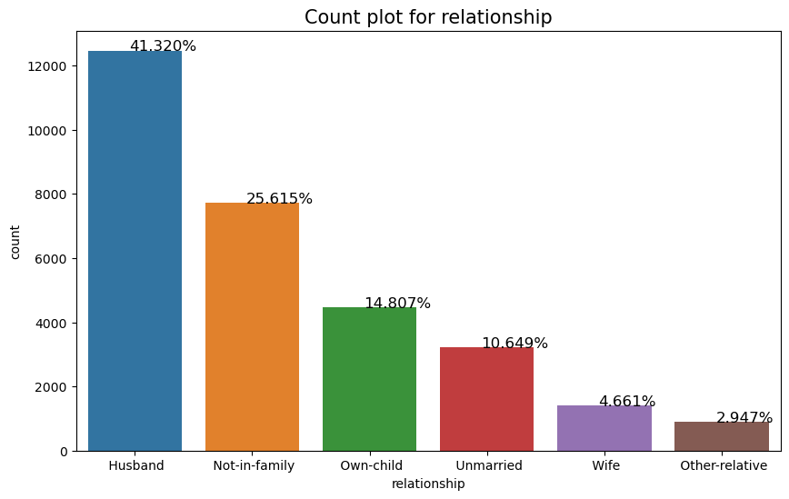

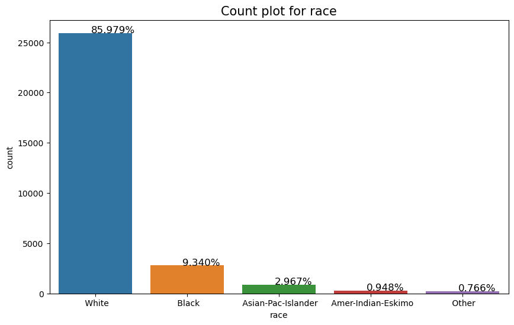

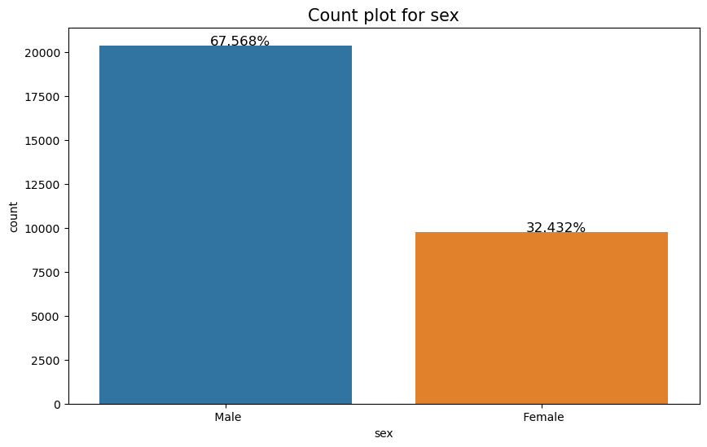

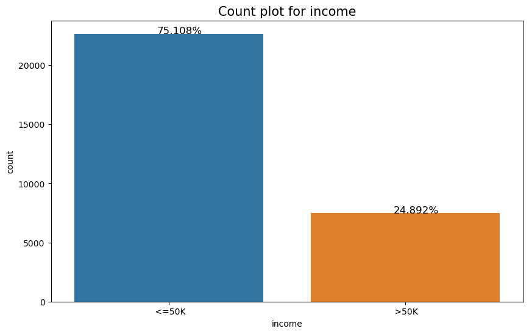

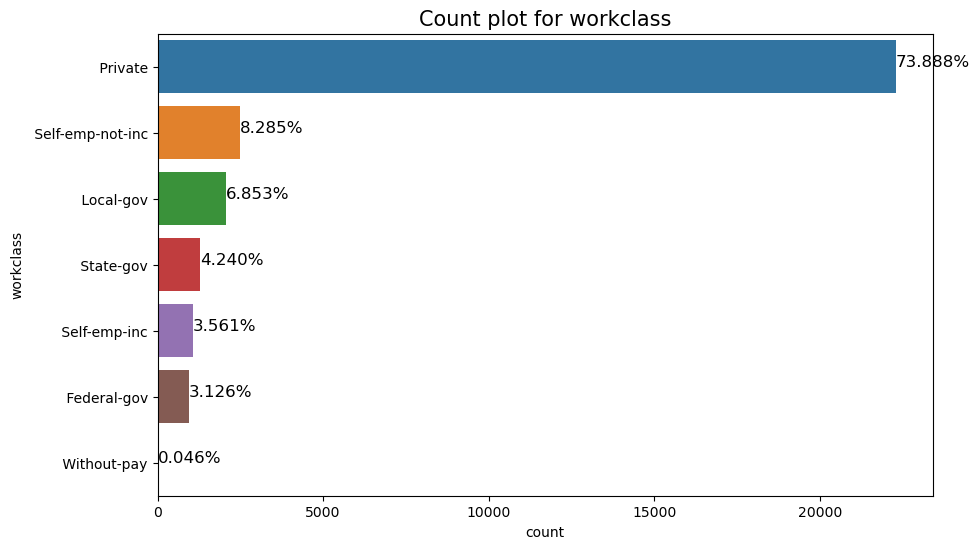

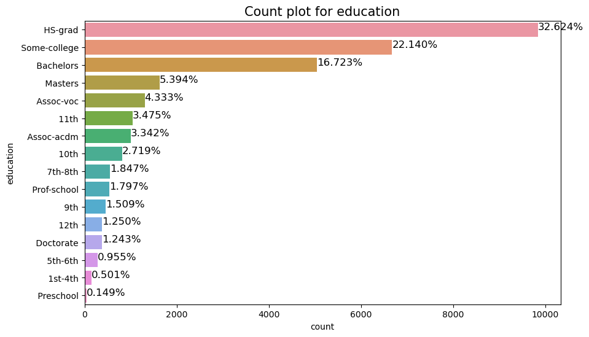

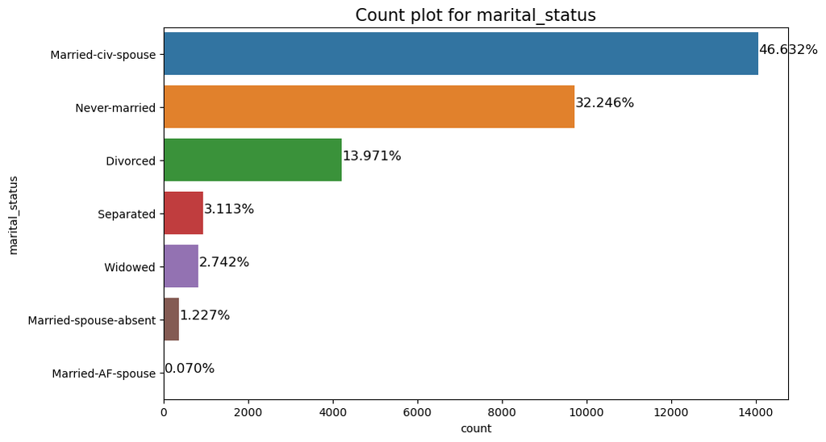

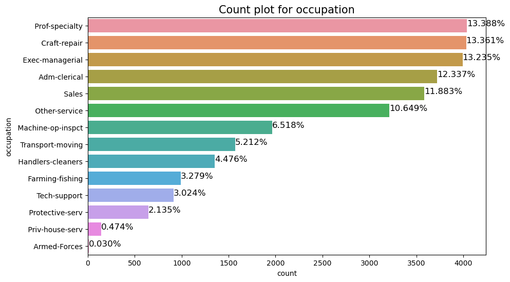

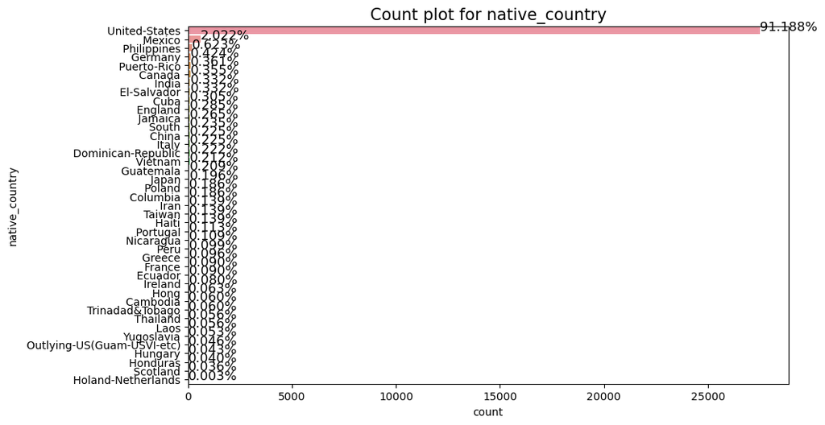

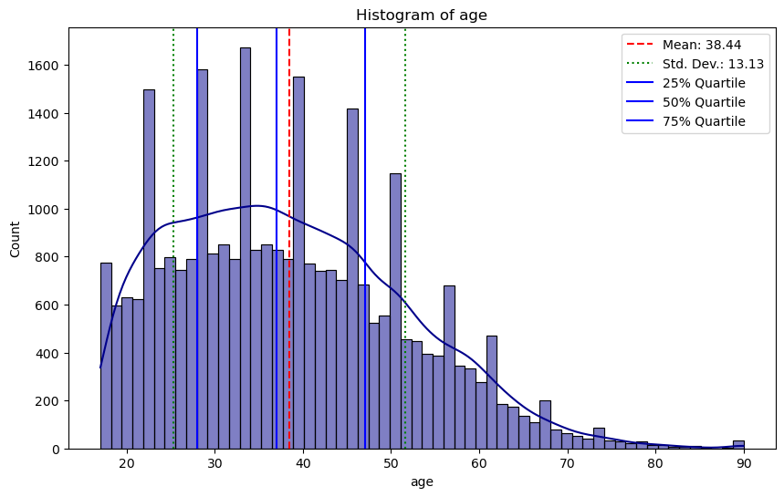

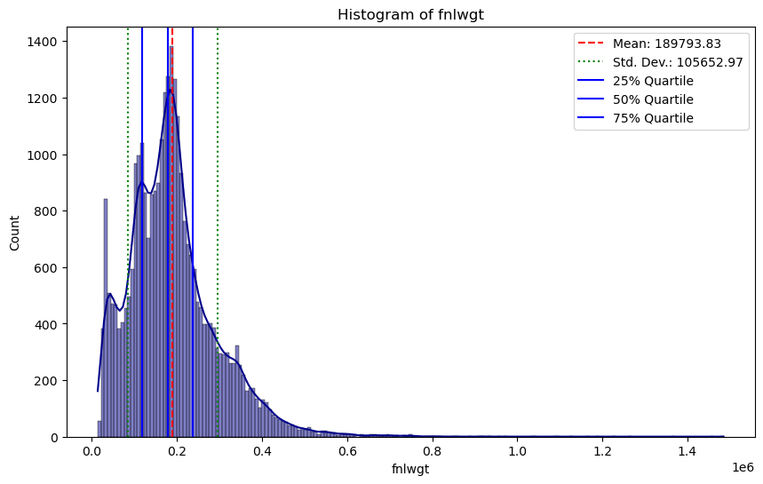

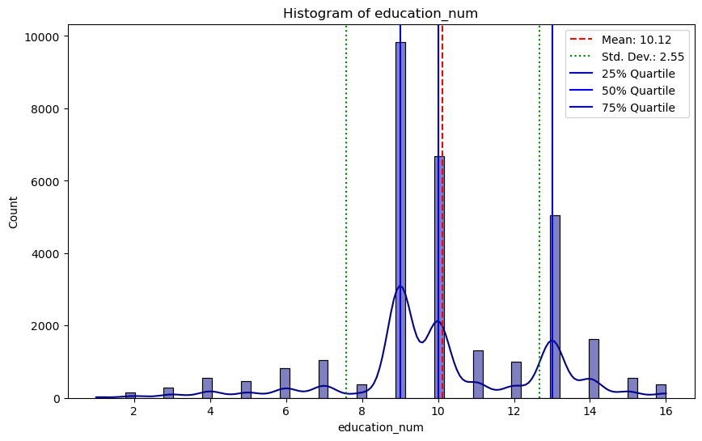

[3 more figures not shown]

```python
# Explore the data with visualizations
# I visualized all the data with vertical bar plots and histograms first, but realized this is not ideal
# I then visualized the data with vertical and horizontal plots and histograms. This makes the visualization easier to absorb

import seaborn as sns
import matplotlib.pyplot as plt

# Define the columns for which I want to create vertical bar plots
vertical_bar_columns = ['relationship', 'race', 'sex', 'income']

# Define the columns for which I want to create horizontal bar plots
horizontal_bar_columns = ['workclass', 'education', 'marital_status', 'occupation', 'native_country']

# Define the columns for which I want to create histograms
histogram_columns = ['age', 'fnlwgt', 'education_num', 'capital_gain', 'capital_loss', 'hours_per_week']

# Loop through the columns for vertical bar plots
for column in vertical_bar_columns:
    plt.figure(figsize=(10,6))
    order = df[column].value_counts().index  # Add this line
    ax = sns.countplot(x=column, data=df, order=order)

    total = len(df[column])

    for p in ax.patches:
        percentage = '{:.3f}%'.format(100 * p.get_height()/total)
        x = p.get_x() + p.get_width() / 2 - 0.05
        y = p.get_y() + p.get_height()
        ax.annotate(percentage, (x, y), size = 12)
    plt.title(f'Count plot for {column}', size=15)
    plt.show()

# Loop through the columns for horizontal bar plots
for column in horizontal_bar_columns:
    plt.figure(figsize=(10,6))
    order = df[column].value_counts().index  # Add this line
    ax = sns.countplot(y=column, data=df, order=order)

    total = len(df[column])

    for p in ax.patches:
        percentage = '{:.3f}%'.format(100 * p.get_width()/total)
        x = p.get_x() + p.get_width()
        y = p.get_y() + p.get_height()/2
        ax.annotate(percentage, (x, y), size = 12)
    plt.title(f'Count plot for {column}', size=15)
    plt.show()


# Loop through the columns for histograms
for col in histogram_columns:
    plt.figure(figsize=(10,6))
    sns.histplot(df[col], kde=True, color = 'darkblue')

    # Calculate the statistics
    mean=df[col].mean()
    std_dev=df[col].std()
    var = df[col].var()
    quartiles = df[col].quantile([0.25,0.5,0.75]).values

    # Add vertical lines for mean, std_dev and quartiles
    plt.axvline(mean, color='r', linestyle='--', label=f'Mean: {mean:.2f}')
    plt.axvline(mean-std_dev, color='g', linestyle=':', label=f'Std. Dev.: {std_dev:.2f}')
    plt.axvline(mean+std_dev, color='g', linestyle=':')
    plt.axvline(quartiles[0], color='b', linestyle='-', label='25% Quartile')
    plt.axvline(quartiles[1], color='b', linestyle='-', label='50% Quartile')
    plt.axvline(quartiles[2], color='b', linestyle='-', label='75% Quartile')

    plt.legend()
    plt.title(f'Histogram of {col}')
    plt.show()
```


### Task 2.2: Explore relationships between ten pairs of columns.

```
Chi-square test between race and income:
Chi-square statistic = 304.2413740892043, p-value = 1.3178285203762715e-64
```

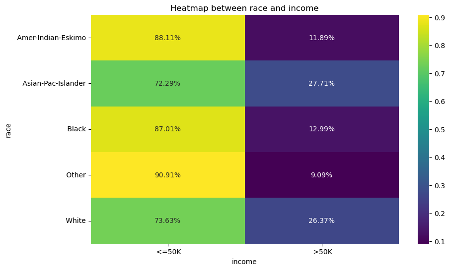

```
Chi-square test between sex and income:
Chi-square statistic = 1415.2864042410245, p-value = 1.00155254124934e-309
```

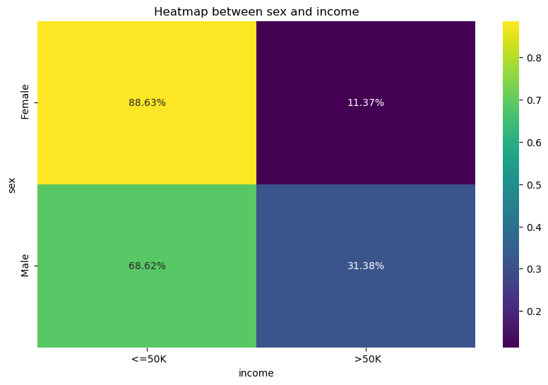

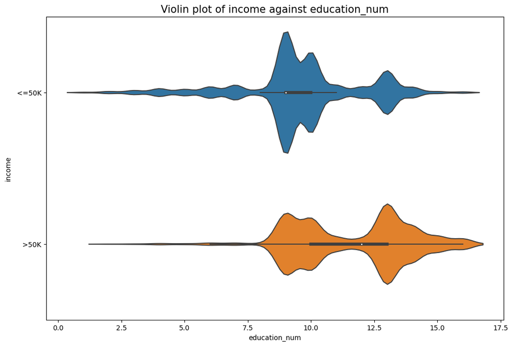

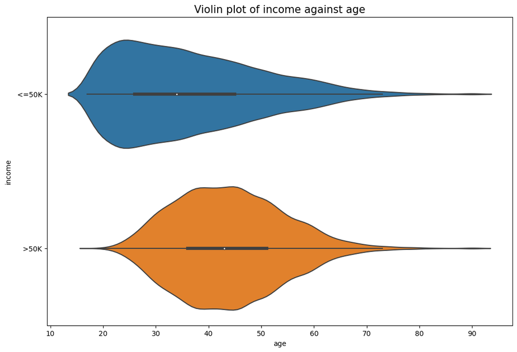

```
Chi-square test between workclass and income:
Chi-square statistic = 804.1575273043354, p-value = 1.946095589239045e-170
```

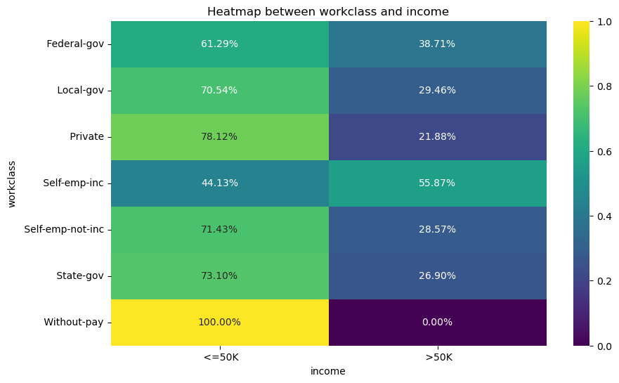

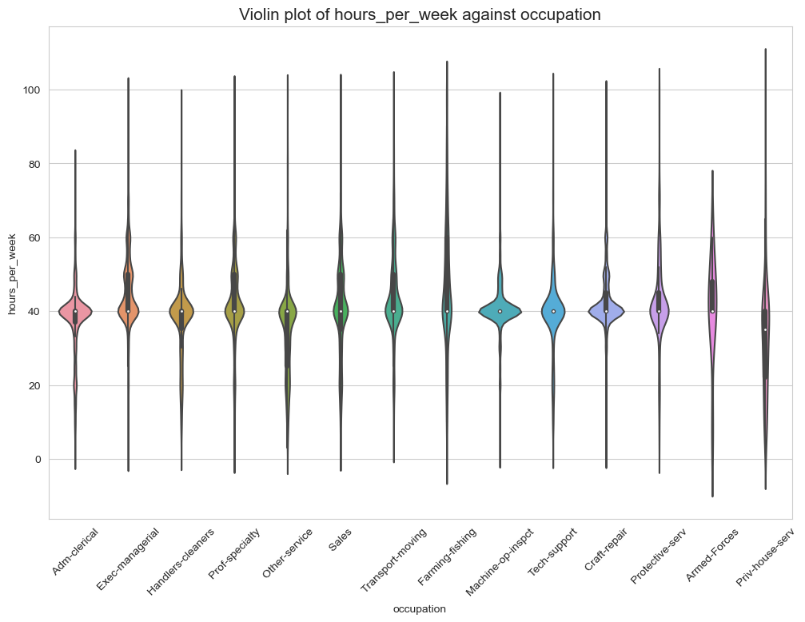

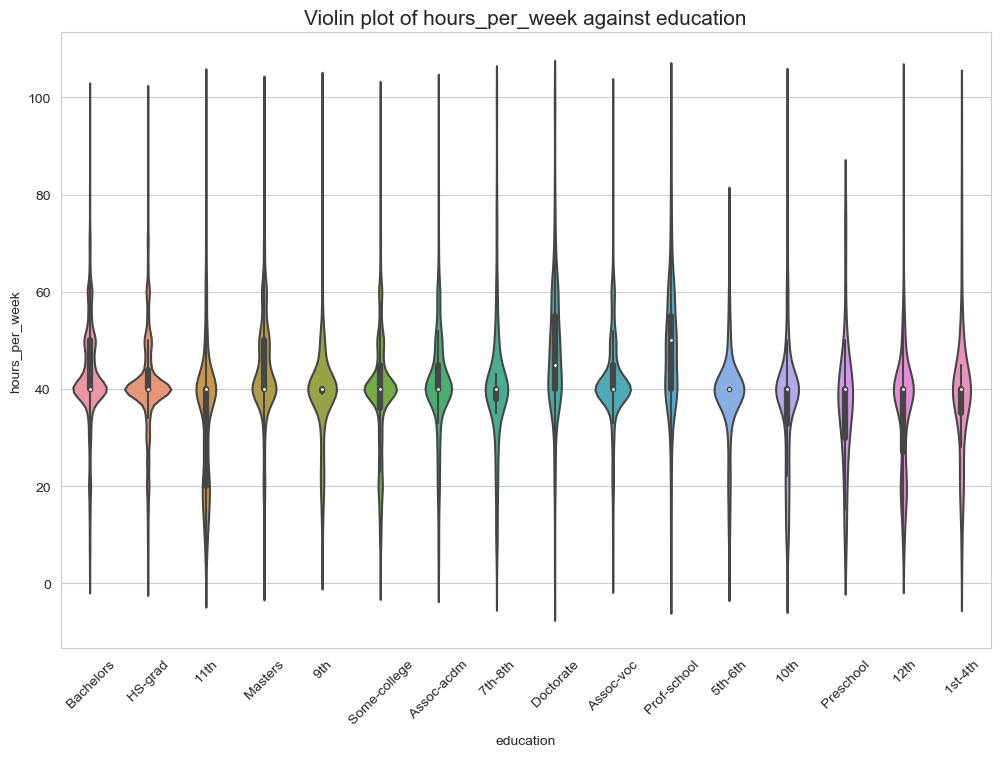

```
Chi-square test between occupation and income:
Chi-square statistic = 3687.620651112799, p-value = 0.0
```

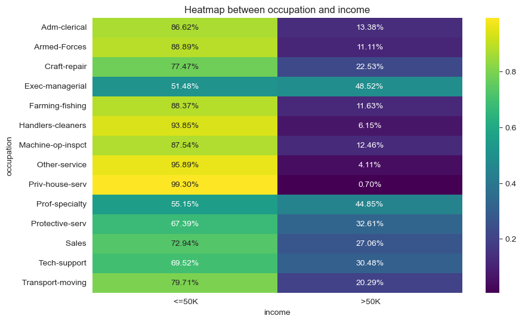

```
Chi-square test between marital_status and income:
Chi-square statistic = 6061.747962669037, p-value = 0.0
```

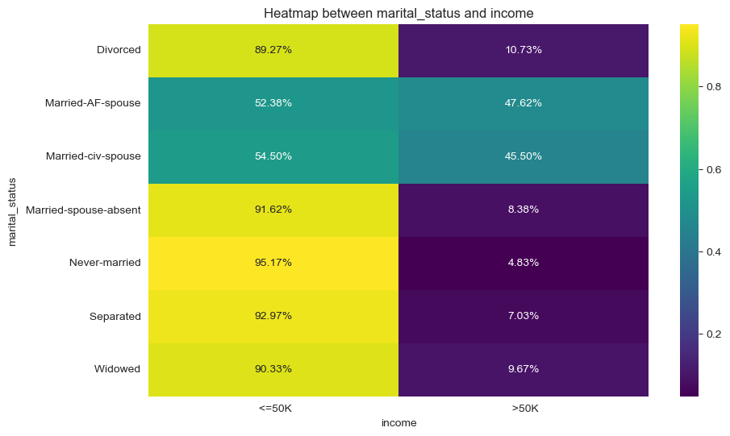

```
Chi-square test between relationship and income:
Chi-square statistic = 6233.8404543499055, p-value = 0.0
```

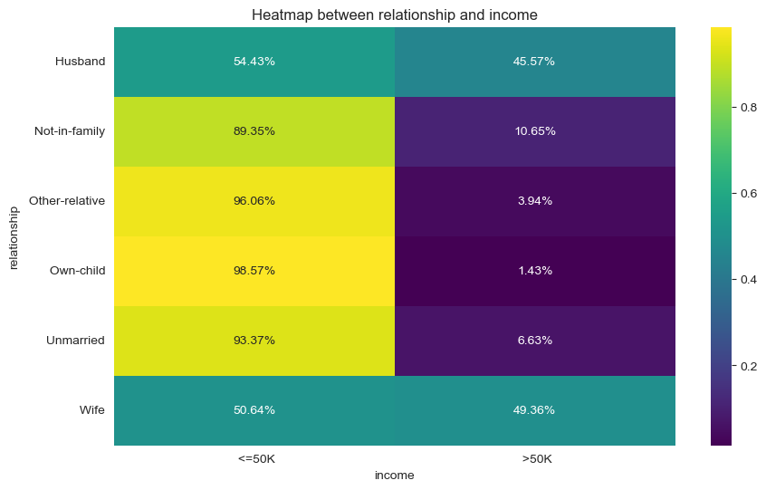

```python
# I will define the pairs I want to work with the create for loops to handle the analysis.

# Define the pairs
pairs = [('race','income'),('sex','income'),('education_num','income'),('age','income'),('workclass','income'),('occupation','hours_per_week'),('education','hours_per_week'),('occupation','income'),('marital_status','income'),('relationship','income')]

# Loop through the pairs
for pair in pairs:
    # For two categorical variables
    if df[pair[0]].dtype == 'object' and df[pair[1]].dtype == 'object':
        # Use crosstab to get the count and percentage of each category
        crosstab = pd.crosstab(df[pair[0]], df[pair[1]], normalize='index')
        crosstab_count = pd.crosstab(df[pair[0]], df[pair[1]])

        # Perform a chi-square test
        chi2, p, dof, ex = stats.chi2_contingency(crosstab_count)
        print(f'Chi-square test between {pair[0]} and {pair[1]}:')
        print(f'Chi-square statistic = {chi2}, p-value = {p}')

        crosstab_percentage = crosstab.applymap(lambda x: "{0:.2f}%".format(100*x))
        crosstab_count = crosstab_count.applymap(lambda x: f"{x:,}")

        # Create a heatmap of the crosstab
        plt.figure(figsize=(10,6))
        sns.heatmap(crosstab, annot=crosstab_percentage, fmt='', cmap='viridis')
        plt.title(f'Heatmap between {pair[0]} and {pair[1]}')
        plt.show()

    # For two numerical variables
    elif df[pair[0]].dtype != 'object' and df[pair[1]].dtype != 'object':
        # Use scatter plot and Pearson correlation
        plt.figure(figsize=(10,6))
        plt.scatter(df[pair[0]], df[pair[1]])
        plt.title(f'Scatter plot between {pair[0]} and {pair[1]}')
        plt.xlabel(pair[0])
        plt.ylabel(pair[1])
        plt.show()
        corr, _ = stats.pearsonr(df[pair[0]], df[pair[1]])
        print(f'Pearson correlation between {pair[0]} and {pair[1]} = {corr}')

    # For categorical vs numerical
    else:
        plt.figure(figsize=(12,8))
        if pair[0] in ['occupation', 'education']:
            sns.set_style("whitegrid")
            plt.xticks(rotation=45)
            plt.tick_params(labelsize=10)
        sns.violinplot(x=df[pair[0]], y=df[pair[1]])
        plt.title(f'Violin plot of {pair[1]} against {pair[0]}', size=15)
        plt.show()
```

### Observations from analysis of data pairs

- According to the Chi-square tests conducted, there are strong evidence to suggest that race, sex, type of employment, occupation, marital status and relationship are significantly associated with income.
- Asia-Pac-Islanders and Whites tend to earn more than 50,000 a year when compared to other races.
- Males tend to earn more than 50,000 a year than females.
- Those in manegerial and professional specialities tend to earn more than any other occupation.
- Those who are married have a higher probability of earning more than 50,000 per year.

## Task 2.3: Posing One Meaningful Question and Seeking an Answer

I will be posing this question: **Is there a significant difference in the number of hours per week worked by males vs females?**

I have selected this because analysis of the relationships above do not give me a clear answer to explain what drives a person's income level.

The null hypothesis is that **there is no difference in the number of hours worked per week by males and females**

I will compute the mean hours worked by males and females, then visualize the distribution of hours per week for both groups and finally perform statistical tests to check if the difference is significant.

```
Mean hours per week for males: 42.85068694798822
Mean hours per week for females: 36.93222244939685
```

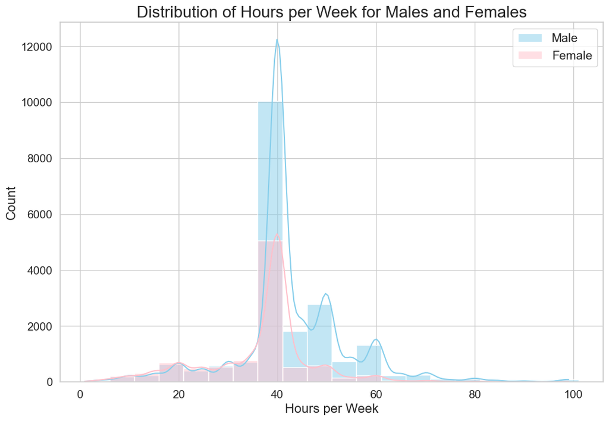

```
T-statistic: 41.2826615806894
P-value: 0.0
There is a significant difference in the number of hours per week worked by males and females.
```

```python
# I will strip the whitespace from the column labels
df['sex'] = df['sex'].str.strip()
# Set a theme from seaborn
sns.set_theme(style="whitegrid")

# Compute the mean hours per week for both males and females
mean_hours_males = df[df['sex'] == 'Male']['hours_per_week'].mean()
mean_hours_females = df[df['sex'] == 'Female']['hours_per_week'].mean()

print(f'Mean hours per week for males: {mean_hours_males}')
print(f'Mean hours per week for females: {mean_hours_females}')

# Visualize the distribution of hours per week for both males and females
plt.figure(figsize=(12, 8))
sns.histplot(df[df['sex'] == 'Male']['hours_per_week'], color='skyblue', label='Male', kde=True, binwidth=5)
sns.histplot(df[df['sex'] == 'Female']['hours_per_week'], color='pink', label='Female', kde=True, binwidth=5)
plt.title('Distribution of Hours per Week for Males and Females', fontsize=20)
plt.xlabel('Hours per Week', fontsize=16)
plt.ylabel('Count', fontsize=16)
plt.legend(prop={'size': 15})
plt.xticks(fontsize=14)
plt.yticks(fontsize=14)
plt.show()

# Perform a statistical test (t-test) to check if the difference is significant
male_hours = df[df['sex'] == 'Male']['hours_per_week']
female_hours = df[df['sex'] == 'Female']['hours_per_week']

t_stat, p_val = stats.ttest_ind(male_hours, female_hours)
print(f'T-statistic: {t_stat}')
print(f'P-value: {p_val}')

if p_val < 0.05:
    print('There is a significant difference in the number of hours per week worked by males and females.')
else:
    print('There is no significant difference in the number of hours per week worked by males and females.')
```

### Observations from the analysis if hours worked per week by males and females

- Males worked more hours per week on average than females
- T-stat of 41.3 indicates significant difference between the mean hours worked by both groups
- P-value shows that null hypothesis can be rejected

## Task 3: Data Modelling

### Task 3.1: Splitting the Data

First I will encode the categorical and numerical variables, normalize the numerical variables and detect and handle outliers. Then I will split the data into three suites of test and training data sets. Then I will implement both the chosen models.

The aim of this is to create models that can predict whether or not a person will earn more and less than 50k a year

```python
# Encode categorical variables
cat_columns = ['workclass', 'education', 'marital_status', 'occupation', 'relationship', 'race', 'sex', 'native_country', 'income']
label_encoder = LabelEncoder()
label_mapping = {}  # To store the mapping of labels to original values

for col in cat_columns:
    df[col] = label_encoder.fit_transform(df[col])
    label_mapping[col] = dict(zip(label_encoder.classes_, label_encoder.transform(label_encoder.classes_)))

# Normalize numerical variables
numerical_columns = ['age', 'fnlwgt', 'education_num', 'capital_gain', 'capital_loss', 'hours_per_week']
scaler = MinMaxScaler()
df[numerical_columns] = scaler.fit_transform(df[numerical_columns])

# Detect and handle outliers
outlier_columns = ['age', 'fnlwgt', 'education_num', 'capital_gain', 'capital_loss', 'hours_per_week']
for col in outlier_columns:
    q1 = df[col].quantile(0.25)
    q3 = df[col].quantile(0.75)
    iqr = q3 - q1
    lower_bound = q1 - 1.5 * iqr
    upper_bound = q3 + 1.5 * iqr
    df = df[(df[col] >= lower_bound) & (df[col] <= upper_bound)]

suite1_X_train, suite1_X_test, suite1_y_train, suite1_y_test = train_test_split(df.drop('income', axis=1), df['income'], test_size=0.5, random_state=42)
suite2_X_train, suite2_X_test, suite2_y_train, suite2_y_test = train_test_split(df.drop('income', axis=1), df['income'], test_size=0.4, random_state=42)
suite3_X_train, suite3_X_test, suite3_y_train, suite3_y_test = train_test_split(df.drop('income', axis=1), df['income'], test_size=0.2, random_state=42)

# Instantiate the models
model1 = LogisticRegression()
model2 = DecisionTreeClassifier()
```

### Suite 1

```
Performance metrics for Suite 1:
Model 1 (Logistic Regression):
Training Set:
Confusion Matrix:
[[4329  107]
 [ 802   89]]
Accuracy: 0.8293598648394969
Precision: 0.45408163265306123
Recall: 0.09988776655443322
F1 Score: 0.16375344986200555
Test Set:
Confusion Matrix:
[[4326   91]
 [ 803  107]]
Accuracy: 0.8321757086540267
Precision: 0.5404040404040404
Recall: 0.11758241758241758
F1 Score: 0.19314079422382668
Model 2 (Decision Tree):
Training Set:
Confusion Matrix:
[[4436    0]
 [   0  891]]
Accuracy: 1.0
Precision: 1.0
Recall: 1.0
F1 Score: 1.0
Test Set:
Confusion Matrix:
[[3869  548]
 [ 520  390]]
Accuracy: 0.7995119204054815
Precision: 0.4157782515991471
Recall: 0.42857142857142855
F1 Score: 0.42207792207792205
```

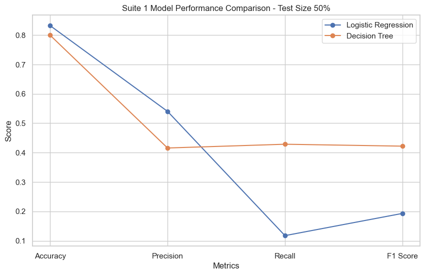

```python
# Train the models on Suite 1
model1.fit(suite1_X_train, suite1_y_train)
model2.fit(suite1_X_train, suite1_y_train)

# Predict on training and test sets
model1_train_predictions = model1.predict(suite1_X_train)
model1_test_predictions = model1.predict(suite1_X_test)
model2_train_predictions = model2.predict(suite1_X_train)
model2_test_predictions = model2.predict(suite1_X_test)

# Evaluate model performance on Suite 1
model1_train_cm = confusion_matrix(suite1_y_train, model1_train_predictions)
model1_train_acc = accuracy_score(suite1_y_train, model1_train_predictions)
model1_train_precision = precision_score(suite1_y_train, model1_train_predictions)
model1_train_recall = recall_score(suite1_y_train, model1_train_predictions)
model1_train_f1 = f1_score(suite1_y_train, model1_train_predictions)

model1_test_cm = confusion_matrix(suite1_y_test, model1_test_predictions)
model1_test_acc = accuracy_score(suite1_y_test, model1_test_predictions)
model1_test_precision = precision_score(suite1_y_test, model1_test_predictions)
model1_test_recall = recall_score(suite1_y_test, model1_test_predictions)
model1_test_f1 = f1_score(suite1_y_test, model1_test_predictions)

model2_train_cm = confusion_matrix(suite1_y_train, model2_train_predictions)
model2_train_acc = accuracy_score(suite1_y_train, model2_train_predictions)
model2_train_precision = precision_score(suite1_y_train, model2_train_predictions)
model2_train_recall = recall_score(suite1_y_train, model2_train_predictions)
model2_train_f1 = f1_score(suite1_y_train, model2_train_predictions)

model2_test_cm = confusion_matrix(suite1_y_test, model2_test_predictions)
model2_test_acc = accuracy_score(suite1_y_test, model2_test_predictions)
model2_test_precision = precision_score(suite1_y_test, model2_test_predictions)
model2_test_recall = recall_score(suite1_y_test, model2_test_predictions)
model2_test_f1 = f1_score(suite1_y_test, model2_test_predictions)

# Print performance metrics for Suite 1
print("Performance metrics for Suite 1:")
print("Model 1 (Logistic Regression):")
print("Training Set:")
print("Confusion Matrix:")
print(model1_train_cm)
print("Accuracy:", model1_train_acc)
print("Precision:", model1_train_precision)
print("Recall:", model1_train_recall)
print("F1 Score:", model1_train_f1)
print("Test Set:")
print("Confusion Matrix:")
print(model1_test_cm)
print("Accuracy:", model1_test_acc)
print("Precision:", model1_test_precision)
print("Recall:", model1_test_recall)
print("F1 Score:", model1_test_f1)

print("Model 2 (Decision Tree):")
print("Training Set:")
print("Confusion Matrix:")
print(model2_train_cm)
print("Accuracy:", model2_train_acc)
print("Precision:", model2_train_precision)
print("Recall:", model2_train_recall)
print("F1 Score:", model2_train_f1)
print("Test Set:")
print("Confusion Matrix:")
print(model2_test_cm)
print("Accuracy:", model2_test_acc)
print("Precision:", model2_test_precision)
print("Recall:", model2_test_recall)
print("F1 Score:", model2_test_f1)

# Compare models using graphical visualizations
plt.figure(figsize=(10, 6))
x = ['Accuracy', 'Precision', 'Recall', 'F1 Score']
model1_scores = [model1_test_acc, model1_test_precision, model1_test_recall, model1_test_f1]
model2_scores = [model2_test_acc, model2_test_precision, model2_test_recall, model2_test_f1]

plt.plot(x, model1_scores, marker='o', label='Logistic Regression')
plt.plot(x, model2_scores, marker='o', label='Decision Tree')
plt.title('Suite 1 Model Performance Comparison - Test Size 50%')
plt.xlabel('Metrics')
plt.ylabel('Score')
plt.legend()
plt.show()
```

### Suite 2

```
Performance metrics for Suite 2:
Model 1 (Logistic Regression):
Training Set:
Confusion Matrix:
[[5219  109]
 [ 969   95]]
Accuracy: 0.831351689612015
Precision: 0.46568627450980393
Recall: 0.08928571428571429
F1 Score: 0.1498422712933754
Test Set:
Confusion Matrix:
[[3474   51]
 [ 657   80]]
Accuracy: 0.8338808071328015
Precision: 0.6106870229007634
Recall: 0.10854816824966079
F1 Score: 0.18433179723502305
Model 2 (Decision Tree):
Training Set:
Confusion Matrix:
[[5328    0]
 [   0 1064]]
Accuracy: 1.0
Precision: 1.0
Recall: 1.0
F1 Score: 1.0
Test Set:
Confusion Matrix:
[[3072  453]
 [ 417  320]]
Accuracy: 0.7958704833411544
Precision: 0.4139715394566624
Recall: 0.43419267299864317
F1 Score: 0.42384105960264906
```

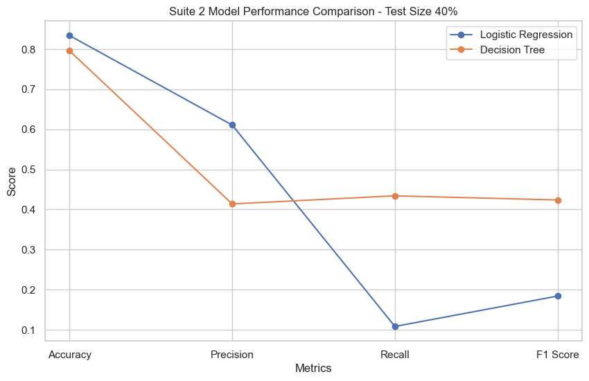

```python
# Train the models on Suite 2
model1.fit(suite2_X_train, suite2_y_train)
model2.fit(suite2_X_train, suite2_y_train)

# Predict on training and test sets
model1_train_predictions = model1.predict(suite2_X_train)
model1_test_predictions = model1.predict(suite2_X_test)
model2_train_predictions = model2.predict(suite2_X_train)
model2_test_predictions = model2.predict(suite2_X_test)

# Evaluate model performance on Suite 2
model1_train_cm = confusion_matrix(suite2_y_train, model1_train_predictions)
model1_train_acc = accuracy_score(suite2_y_train, model1_train_predictions)
model1_train_precision = precision_score(suite2_y_train, model1_train_predictions)
model1_train_recall = recall_score(suite2_y_train, model1_train_predictions)
model1_train_f1 = f1_score(suite2_y_train, model1_train_predictions)

model1_test_cm = confusion_matrix(suite2_y_test, model1_test_predictions)
model1_test_acc = accuracy_score(suite2_y_test, model1_test_predictions)
model1_test_precision = precision_score(suite2_y_test, model1_test_predictions)
model1_test_recall = recall_score(suite2_y_test, model1_test_predictions)
model1_test_f1 = f1_score(suite2_y_test, model1_test_predictions)

model2_train_cm = confusion_matrix(suite2_y_train, model2_train_predictions)
model2_train_acc = accuracy_score(suite2_y_train, model2_train_predictions)
model2_train_precision = precision_score(suite2_y_train, model2_train_predictions)
model2_train_recall = recall_score(suite2_y_train, model2_train_predictions)
model2_train_f1 = f1_score(suite2_y_train, model2_train_predictions)

model2_test_cm = confusion_matrix(suite2_y_test, model2_test_predictions)
model2_test_acc = accuracy_score(suite2_y_test, model2_test_predictions)
model2_test_precision = precision_score(suite2_y_test, model2_test_predictions)
model2_test_recall = recall_score(suite2_y_test, model2_test_predictions)
model2_test_f1 = f1_score(suite2_y_test, model2_test_predictions)

# Print performance metrics for Suite 2
print("Performance metrics for Suite 2:")
print("Model 1 (Logistic Regression):")
print("Training Set:")
print("Confusion Matrix:")
print(model1_train_cm)
print("Accuracy:", model1_train_acc)
print("Precision:", model1_train_precision)
print("Recall:", model1_train_recall)
print("F1 Score:", model1_train_f1)
print("Test Set:")
print("Confusion Matrix:")
print(model1_test_cm)
print("Accuracy:", model1_test_acc)
print("Precision:", model1_test_precision)
print("Recall:", model1_test_recall)
print("F1 Score:", model1_test_f1)

print("Model 2 (Decision Tree):")
print("Training Set:")
print("Confusion Matrix:")
print(model2_train_cm)
print("Accuracy:", model2_train_acc)
print("Precision:", model2_train_precision)
print("Recall:", model2_train_recall)
print("F1 Score:", model2_train_f1)
print("Test Set:")
print("Confusion Matrix:")
print(model2_test_cm)
print("Accuracy:", model2_test_acc)
print("Precision:", model2_test_precision)
print("Recall:", model2_test_recall)
print("F1 Score:", model2_test_f1)

plt.figure(figsize=(10, 6))
x = ['Accuracy', 'Precision', 'Recall', 'F1 Score']
model1_scores = [model1_test_acc, model1_test_precision, model1_test_recall, model1_test_f1]
model2_scores = [model2_test_acc, model2_test_precision, model2_test_recall, model2_test_f1]

plt.plot(x, model1_scores, marker='o', label='Logistic Regression')
plt.plot(x, model2_scores, marker='o', label='Decision Tree')
plt.title('Suite 2 Model Performance Comparison - Test Size 40%')
plt.xlabel('Metrics')
plt.ylabel('Score')
plt.legend()
plt.show()
```

### Suite 3

```
Performance metrics for Suite 3:
Model 1 (Logistic Regression):
Training Set:
Confusion Matrix:
[[6937  139]
 [1313  134]]
Accuracy: 0.8296374516015488
Precision: 0.4908424908424908
Recall: 0.09260539046302695
F1 Score: 0.1558139534883721
Test Set:
Confusion Matrix:
[[1752   25]
 [ 319   35]]
Accuracy: 0.8385734396996715
Precision: 0.5833333333333334
Recall: 0.09887005649717515
F1 Score: 0.16908212560386474
Model 2 (Decision Tree):
Training Set:
Confusion Matrix:
[[7076    0]
 [   1 1446]]
Accuracy: 0.9998826704212131
Precision: 1.0
Recall: 0.9993089149965446
F1 Score: 0.9996543380573799
Test Set:
Confusion Matrix:
[[1527  250]
 [ 206  148]]
Accuracy: 0.7860159549507274
Precision: 0.37185929648241206
Recall: 0.4180790960451977
F1 Score: 0.3936170212765957
```

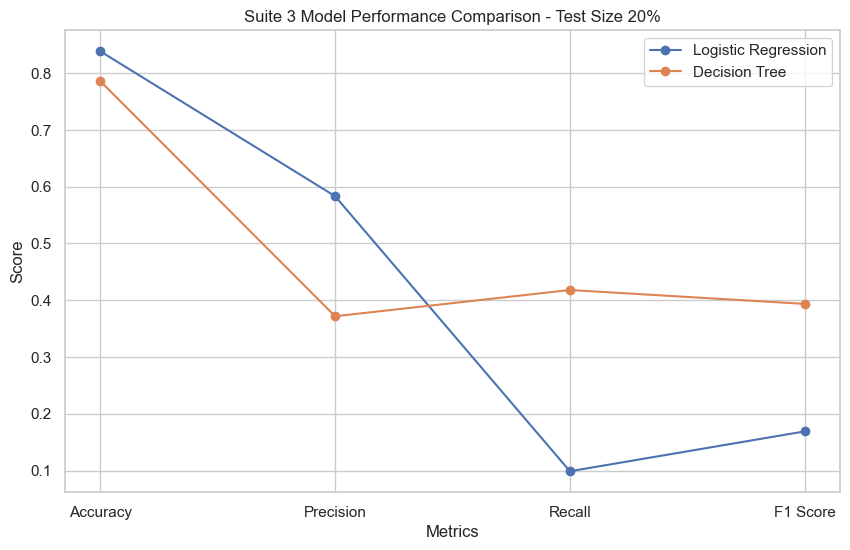

```python
# Train the models on Suite 3
model1.fit(suite3_X_train, suite3_y_train)
model2.fit(suite3_X_train, suite3_y_train)

# Predict on training and test sets
model1_train_predictions = model1.predict(suite3_X_train)
model1_test_predictions = model1.predict(suite3_X_test)
model2_train_predictions = model2.predict(suite3_X_train)
model2_test_predictions = model2.predict(suite3_X_test)

# Evaluate model performance on Suite 3
model1_train_cm = confusion_matrix(suite3_y_train, model1_train_predictions)
model1_train_acc = accuracy_score(suite3_y_train, model1_train_predictions)
model1_train_precision = precision_score(suite3_y_train, model1_train_predictions)
model1_train_recall = recall_score(suite3_y_train, model1_train_predictions)
model1_train_f1 = f1_score(suite3_y_train, model1_train_predictions)

model1_test_cm = confusion_matrix(suite3_y_test, model1_test_predictions)
model1_test_acc = accuracy_score(suite3_y_test, model1_test_predictions)
model1_test_precision = precision_score(suite3_y_test, model1_test_predictions)
model1_test_recall = recall_score(suite3_y_test, model1_test_predictions)
model1_test_f1 = f1_score(suite3_y_test, model1_test_predictions)

model2_train_cm = confusion_matrix(suite3_y_train, model2_train_predictions)
model2_train_acc = accuracy_score(suite3_y_train, model2_train_predictions)
model2_train_precision = precision_score(suite3_y_train, model2_train_predictions)
model2_train_recall = recall_score(suite3_y_train, model2_train_predictions)
model2_train_f1 = f1_score(suite3_y_train, model2_train_predictions)

model2_test_cm = confusion_matrix(suite3_y_test, model2_test_predictions)
model2_test_acc = accuracy_score(suite3_y_test, model2_test_predictions)
model2_test_precision = precision_score(suite3_y_test, model2_test_predictions)
model2_test_recall = recall_score(suite3_y_test, model2_test_predictions)
model2_test_f1 = f1_score(suite3_y_test, model2_test_predictions)

# Print performance metrics for Suite 3
print("Performance metrics for Suite 3:")
print("Model 1 (Logistic Regression):")
print("Training Set:")
print("Confusion Matrix:")
print(model1_train_cm)
print("Accuracy:", model1_train_acc)
print("Precision:", model1_train_precision)
print("Recall:", model1_train_recall)
print("F1 Score:", model1_train_f1)
print("Test Set:")
print("Confusion Matrix:")
print(model1_test_cm)
print("Accuracy:", model1_test_acc)
print("Precision:", model1_test_precision)
print("Recall:", model1_test_recall)
print("F1 Score:", model1_test_f1)

print("Model 2 (Decision Tree):")
print("Training Set:")
print("Confusion Matrix:")
print(model2_train_cm)
print("Accuracy:", model2_train_acc)
print("Precision:", model2_train_precision)
print("Recall:", model2_train_recall)
print("F1 Score:", model2_train_f1)
print("Test Set:")
print("Confusion Matrix:")
print(model2_test_cm)
print("Accuracy:", model2_test_acc)
print("Precision:", model2_test_precision)
print("Recall:", model2_test_recall)
print("F1 Score:", model2_test_f1)

plt.figure(figsize=(10, 6))
x = ['Accuracy', 'Precision', 'Recall', 'F1 Score']
model1_scores = [model1_test_acc, model1_test_precision, model1_test_recall, model1_test_f1]
model2_scores = [model2_test_acc, model2_test_precision, model2_test_recall, model2_test_f1]

plt.plot(x, model1_scores, marker='o', label='Logistic Regression')
plt.plot(x, model2_scores, marker='o', label='Decision Tree')
plt.title('Suite 3 Model Performance Comparison - Test Size 20%')
plt.xlabel('Metrics')
plt.ylabel('Score')
plt.legend()
plt.show()
```